# Uganda Population Map Metadata Report

## Prediction Weighting Layer Used in Population Redistribution

The data presented below represent the predicted number of people per ~100 m pixel as estimated using the random forest (RF) model as described in Stevens, et al. (In Press). The following pages contain a description of the RF model and its covariates, their sources and any metadata collected for each covariate. The prediction weighting layer is used to dasymetrically redistribute the census counts and project counts to match estimated populations based on UN estimates for the final population maps provided by AfriPop, AsiaPop and AmeriPop.

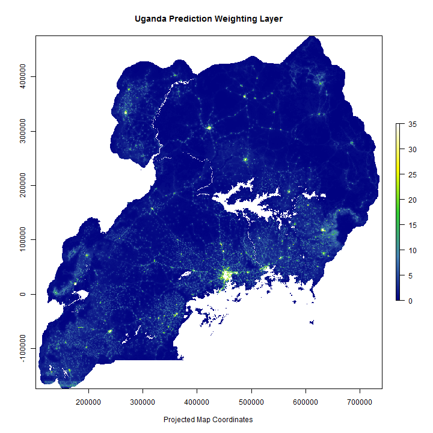

## Uganda Census Data and Observed Population Density

These data are the population density values used to estimate the RF model used to create the prediction weighting layer you see above. Values represent population density as measured by people per hectare and calculated from population counts within each census unit. These values are used as the dependent variable during model estimation.

### Uganda Census Data, 2002, Admin-level 4

**Folder:** Census  
**File Name:** adminpop.shp  
**Source:** Uganda Bureau of Statistics  
**Description:** These census data were acquired by A. Tatem (Tatem et al. 2007). Required fields for map production are ADMINID and ADMINPOP.  
**Class:** polygon  
**Derived Covariates:**  
area, buff, zones,

```
class       : SpatialPolygonsDataFrame
nfeatures   : 5180
extent      : 118314, 725169, -164271, 465900  (xmin, xmax, ymin, ymax)
coord. ref. : NA
nvariables  : 19
```

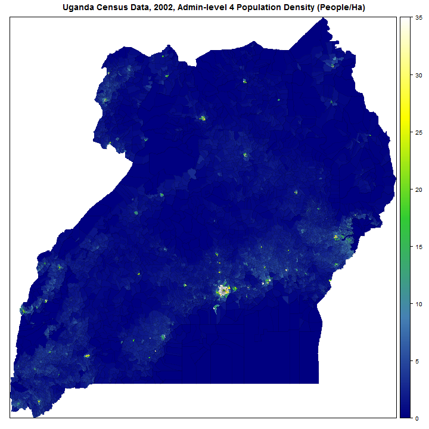

## Random Forest Model and Diagnostics

These output and figures outline the estimated RF model that is used to predict the population density weighting layer. The model is fitted to the population density values for the preceding census data using covariates aggregatedfrom the ancillary data sources summarized following the model diagnostics.

```
Call:
 randomForest(x = x_data, y = y_data, ntree = popfit$ntree, mtry = popfit$mtry,      nodesize = length(y_data)/1000, importance = TRUE, proximity = TRUE)
               Type of random forest: regression
                     Number of trees: 500
No. of variables tried at each split: 12

          Mean of squared residuals: 0.23
                    % Var explained: 85
```

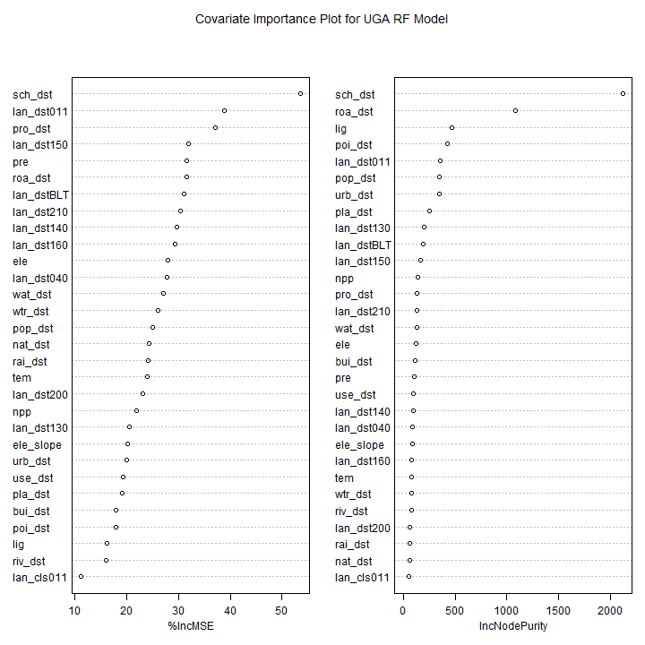

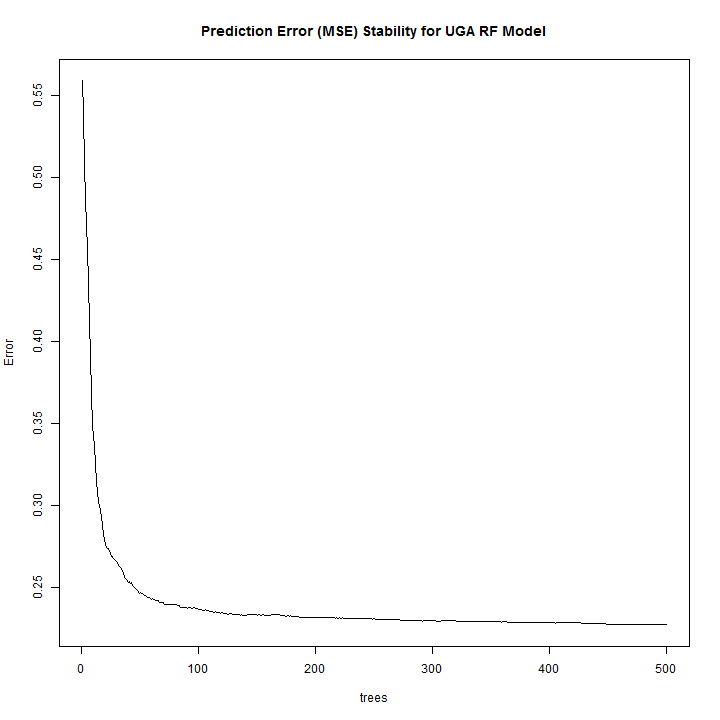

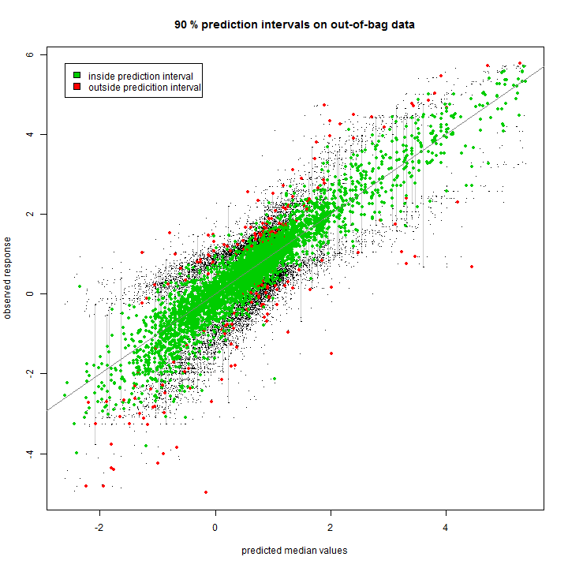

## Covariate Metadata

### Uganda Classified Land Cover

**Folder:** Landcover  
**File Name:** uga_lc.tif  
**Source:** GlobCover, 300m  
**Description:** Landcover from the GlobCover product resampled to 100m, refined with detailed Landsat-derived settlement extents (Tatem et al. 2004,2005), reclassified to match AfriPop coding and eventually broken down into binary classifications by aggregated land cover type (see Linard, et al., 2010 and Gaughan, et al. 2013 for category information).  
**Class:** raster  
**Derived Covariates:**  
prp011, cls011, dst011, prp040, cls040, dst040, prp130, cls130, dst130, prp140, cls140, dst140, prp150, cls150, dst150, prp160, cls160, dst160, prp190, cls190, dst190, prp200, cls200, dst200, prp210, cls210, dst210, prp230, cls230, dst230, prp240, cls240, dst240, prp250, cls250, dst250, prpBLT, clsBLT, dstBLT,

```
class       : RasterBrick
dimensions  : 6502, 6269, 40761038, 1  (nrow, ncol, ncell, nlayers)
resolution  : 100, 100  (x, y)
extent      : 108305, 735205, -174296, 475904  (xmin, xmax, ymin, ymax)
coord. ref. : +proj=utm +zone=36 +datum=WGS84 +units=m +no_defs +ellps=WGS84 +towgs84=0,0,0
data source : E:\APRF\version1.0\RF\data\UGA\Landcover\Derived\landcover.tif
names       : landcover
min values  :        11
max values  :       240
```

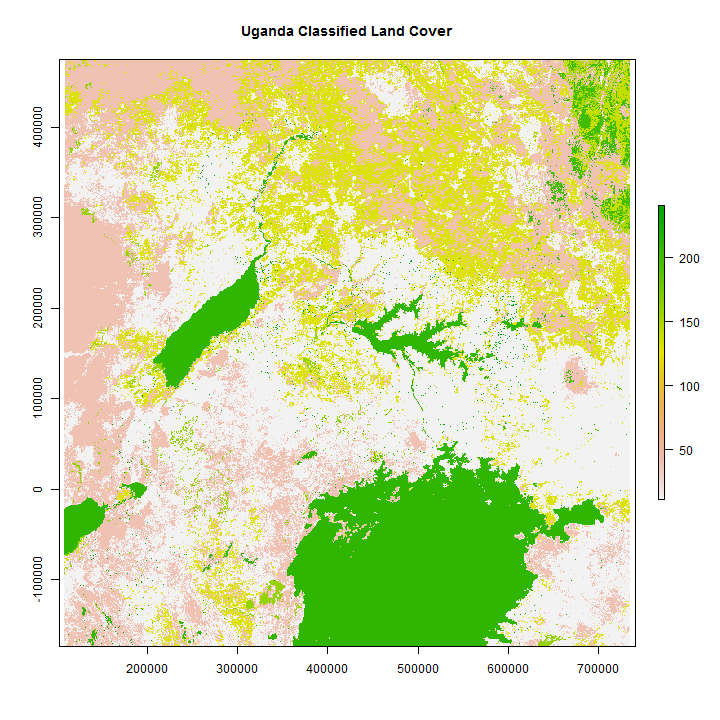

### MODIS 17A3 2010 Estimated Net Primary Productivity, 1km

**Folder:** NPP  
**File Name:** DEFAULT: MODIS 17A3 2010  
**Source:** United States Geological Survey (USGS)  
**Description:** MODIS 17A3 version-55 derived estimates of net primary productivity for the year 2010, estimated for 1km pixel sizes and subset and resampled to match the available land cover and final population map output requirements.  
**Class:** raster  
**Derived Covariates:**  
,

```
class       : RasterBrick
dimensions  : 6503, 6271, 40780313, 1  (nrow, ncol, ncell, nlayers)
resolution  : 100, 100  (x, y)
extent      : 108205, 735305, -174296, 476004  (xmin, xmax, ymin, ymax)
coord. ref. : +proj=utm +zone=36 +datum=WGS84 +units=m +no_defs +ellps=WGS84 +towgs84=0,0,0
data source : E:\APRF\version1.0\RF\data\UGA\NPP\Derived\npp.tif
names       :   npp
min values  :     0
max values  : 22111
```

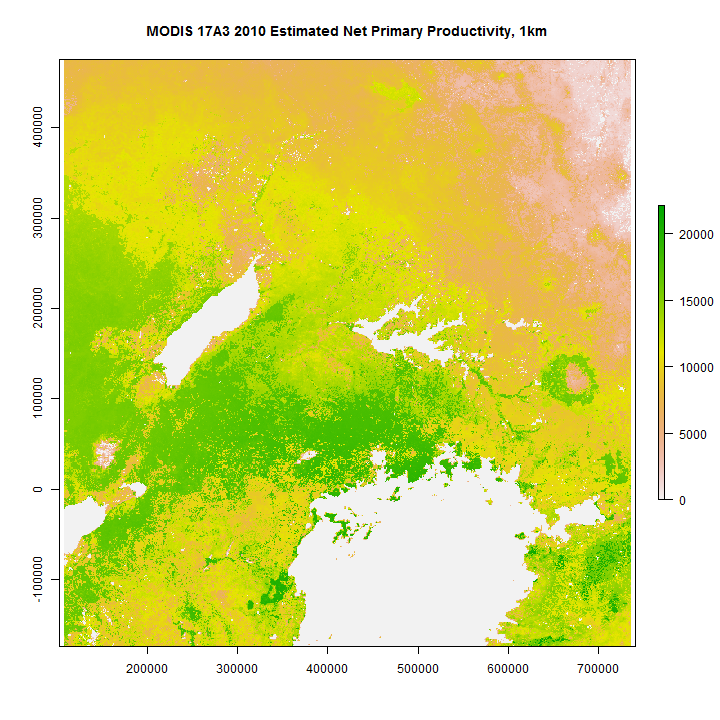

### Suomi NPP VIIRS-Derived 2012 Lights at Night, 15 arc-second

**Folder:** Lights  
**File Name:** DEFAULT: VIIRS 2012  
**Source:** http://ngdc.noaa.gov/eog/viirs/download_viirs_ntl.html  
**Description:** These 'Lights at Night' data were derived from imagery collected by the Suomi National Polar-orbiting Partnership (NPP) Visible Infrared Imaging Radiometer Suite (VIIRS) sensor. Data were collected in 2012 on moonless nights and though background noise associated with fires, gas-flares, volcanoes or aurora have not been removed it represents the best-available data for night-time light production.  
**Class:** raster  
**Derived Covariates:**  
,

[output not shown]

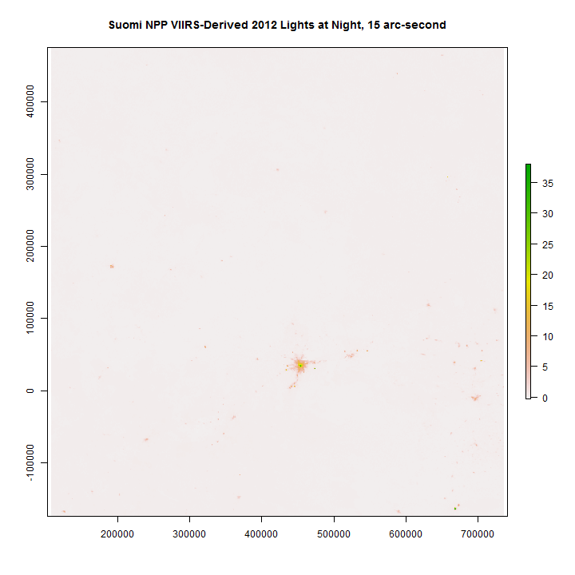

### WorldClim/BioClim Mean Annual Temperature 1950-2000, 30 arc-second

**Folder:** Temp  
**File Name:** DEFAULT: BIO1  
**Source:** http://www.worldclim.org/current  
**Description:** WorldClim/BioClim 1950-2000 mean annual precipitation (BIO12) and mean annual temperature (BIO1) estimates (Hijmans et al., 2005) were downloaded, mosaicked and subset to match the extent of our land cover data for the mapping of this region.  
**Class:** raster  
**Derived Covariates:**  
,

```
class       : RasterBrick
dimensions  : 6503, 6271, 40780313, 1  (nrow, ncol, ncell, nlayers)
resolution  : 100, 100  (x, y)
extent      : 108205, 735305, -174296, 476004  (xmin, xmax, ymin, ymax)
coord. ref. : +proj=utm +zone=36 +datum=WGS84 +units=m +no_defs +ellps=WGS84 +towgs84=0,0,0
data source : E:\APRF\version1.0\RF\data\UGA\Temp\Derived\temp.tif
names       : temp
min values  :   23
max values  :  281
```

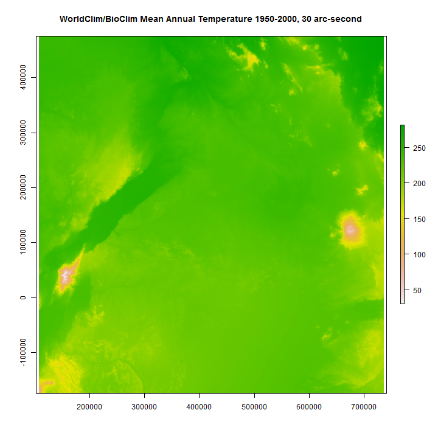

### WorldClim/BioClim Mean Annual Precipitation 1950-2000, 30 arc-second

**Folder:** Precip  
**File Name:** DEFAULT: BIO12  
**Source:** http://www.worldclim.org/current  
**Description:** WorldClim/BioClim 1950-2000 mean annual precipitation (BIO12) and mean annual temperature (BIO1) estimates (Hijmans et al., 2005) were downloaded, mosaicked and subset to match the extent of our land cover data for the mapping of this region.  
**Class:** raster  
**Derived Covariates:**  
,

```
class       : RasterBrick
dimensions  : 6503, 6271, 40780313, 1  (nrow, ncol, ncell, nlayers)
resolution  : 100, 100  (x, y)
extent      : 108205, 735305, -174296, 476004  (xmin, xmax, ymin, ymax)
coord. ref. : +proj=utm +zone=36 +datum=WGS84 +units=m +no_defs +ellps=WGS84 +towgs84=0,0,0
data source : E:\APRF\version1.0\RF\data\UGA\Precip\Derived\precip.tif
names       : precip
min values  :    263
max values  :   2294
```

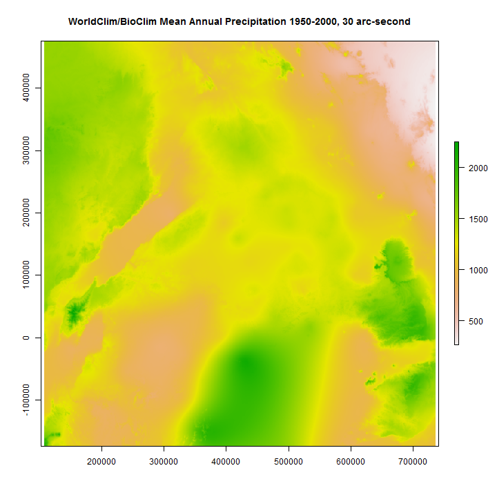

### Roads (OSM), 2013

**Folder:** Roads  
**File Name:** roads.shp  
**Source:** Open Street Map, Downloaded 2013-08-08, http://extract.bbbike.org/  
**Description:** These data were downloaded as part of a per-country package of data layers made availalble as shapefiles through the http://extract.bbbike.org website, extracted from the Open Street Map (OSM) database.  
**Class:** linear  
**Derived Covariates:**  
prp, cls, dst,

```
class       : SpatialLinesDataFrame
nfeatures   : 31430
extent      : 108316, 733108, -173881, 473702  (xmin, xmax, ymin, ymax)
coord. ref. : NA
nvariables  : 7
```

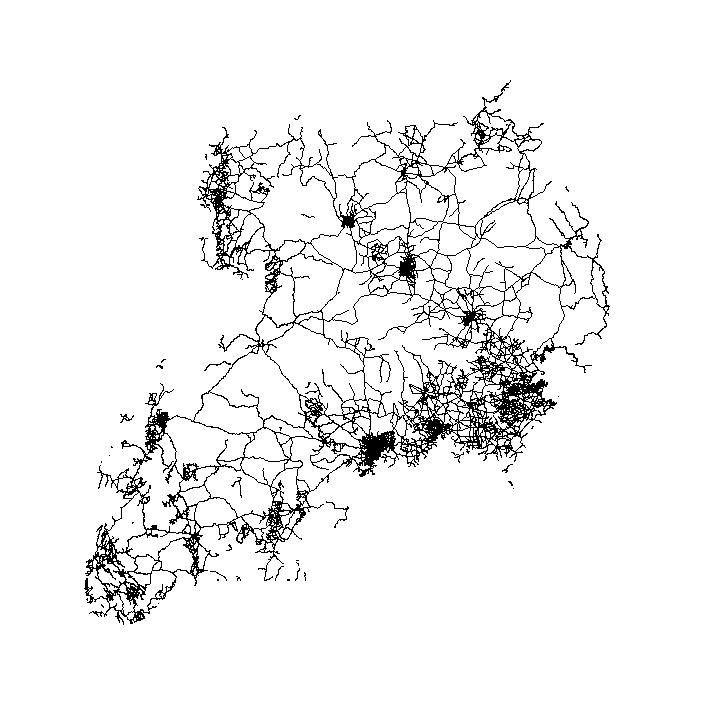

### River Network

**Folder:** Rivers  
**File Name:** DEFAULT: hydro/watrcrsl  
**Source:** National Geospatial-Intelligence Agency (NGA), http://geoengine.nga.mil/geospatial/SW_TOOLS/NIMAMUSE/webinter/rast_roam.html  
**Description:** The VMAP0 data area downloaded as separate files, grouped roughly by continent, and merged into individual shapefiles for subsetting and further processing for population mapping efforts. These data were obtained directly from the original VMAP0 data sources provided by the NGA and pre-processed using Military Analyst in ArcGIS 10.0.  
**Class:** linear  
**Derived Covariates:**  
dst,

```
class       : SpatialLinesDataFrame
nfeatures   : 1497
extent      : 109752, 734320, -174206, 474179  (xmin, xmax, ymin, ymax)
coord. ref. : NA
nvariables  : 9
```

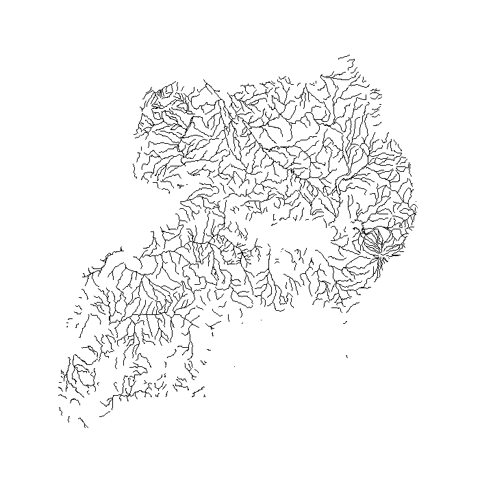

### Populated Places

**Folder:** Populated  
**File Name:** DEFAULT: Merged pop/builtupp, pop/builtupa, pop/mispopp  
**Source:** National Geospatial-Intelligence Agency (NGA), http://geoengine.nga.mil/geospatial/SW_TOOLS/NIMAMUSE/webinter/rast_roam.html  
**Description:** The VMAP0 data area downloaded as separate files, grouped roughly by continent, and merged into individual shapefiles for subsetting and further processing for population mapping efforts. These data were obtained directly from the original VMAP0 data sources provided by the NGA and pre-processed using Military Analyst in ArcGIS 10.0. Point data sources are buffered to 100 m and then all polygon data sources are merged to a single shapefile prior to processing.  
**Class:** polygon  
**Derived Covariates:**  
cls, dst, prp,

```
class       : SpatialPolygonsDataFrame
nfeatures   : 472
extent      : 111821, 714470, -145636, 421291  (xmin, xmax, ymin, ymax)
coord. ref. : NA
nvariables  : 12
```

### Inland Waterbodies

```
class       : SpatialPolygonsDataFrame
nfeatures   : 89
extent      : 116779, 636864, -162194, 379968  (xmin, xmax, ymin, ymax)
coord. ref. : NA
nvariables  : 10
```

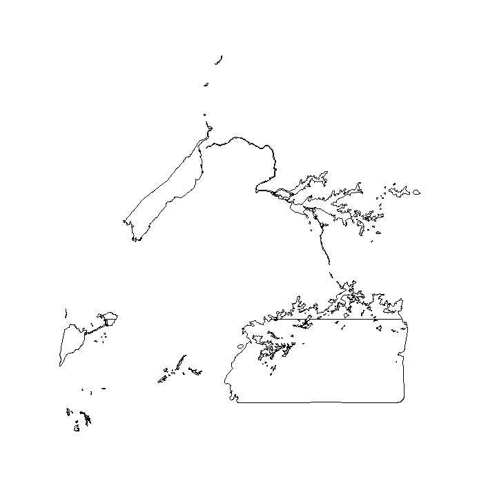

### Protected Areas

**Folder:** Protected  
**File Name:** DEFAULT: WDPAfgdb_Sept2012.gdb  
**Source:** World Database on Protected Areas, Downloaded September, 2012, UNEP, http://www.wdpa.org, http://protectedplanet.net  
**Description:** These data are compiled by UNEP and distributed via the Protected Planet website. All protected areas were downloaded regardless of International Union for Conservation of Nature (IUCN) or any other designation, so they include sanctuaries, national parks, game reserves, World Heritage Sites, etc.  
**Class:** polygon  
**Derived Covariates:**  
cls, dst, prp,

```
class       : SpatialPolygonsDataFrame
nfeatures   : 56
extent      : 108841, 725144, -159511, 448728  (xmin, xmax, ymin, ymax)
coord. ref. : NA
nvariables  : 26
```

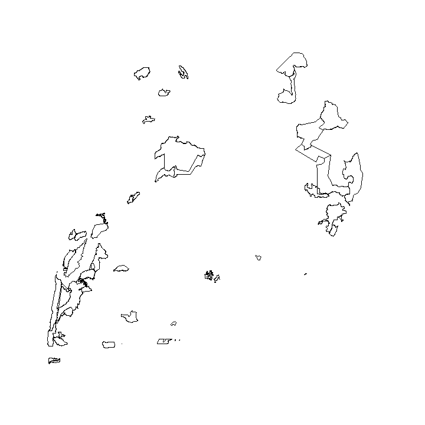

### Urban Extents

**Folder:** Urban  
**File Name:** DEFAULT: schneider-urban.shp  
**Source:** Schneider, et al., United Nations  
**Description:** These data were constructed from MODIS-derived imagery and provided to WorldPop researchers by Schneider, et al. as part of a global urban extents datasets.  
**Class:** polygon  
**Derived Covariates:**  
cls, dst, prp,

```
class       : SpatialPolygonsDataFrame
nfeatures   : 176
extent      : 117063, 632874, -140344, 403929  (xmin, xmax, ymin, ymax)
coord. ref. : NA
nvariables  : 2
```

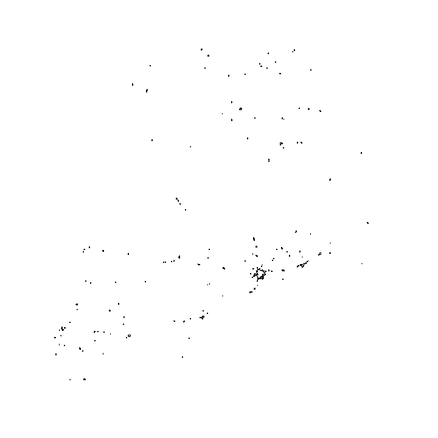

### Elevation and Derived Slope, 3 second

**Folder:** Elevation  
**File Name:** DEFAULT: Void-Filled DEM.gdb  
**Source:** HydroSHEDS Void-Filled DEM (Lehnert, et al., 2006), http://hydrosheds.cr.usgs.gov/dataavail.php  
**Description:** The HydroSHEDS data are the result of an effort to provide a globally consistent dataset consisting of NASA's Shuttle Radar Topography Mission (SRTM) data and have been processed, void-filled and corrected for use at large scales.  
**Class:** raster  
**Derived Covariates:**  
, slope,

```
class       : RasterBrick
dimensions  : 6503, 6271, 40780313, 1  (nrow, ncol, ncell, nlayers)
resolution  : 100, 100  (x, y)
extent      : 108205, 735305, -174296, 476004  (xmin, xmax, ymin, ymax)
coord. ref. : +proj=utm +zone=36 +datum=WGS84 +units=m +no_defs +ellps=WGS84 +towgs84=0,0,0
data source : E:\APRF\version1.0\RF\data\UGA\Elevation\Derived\elevation.tif
names       : elevation
min values  :       480
max values  :      4840
```

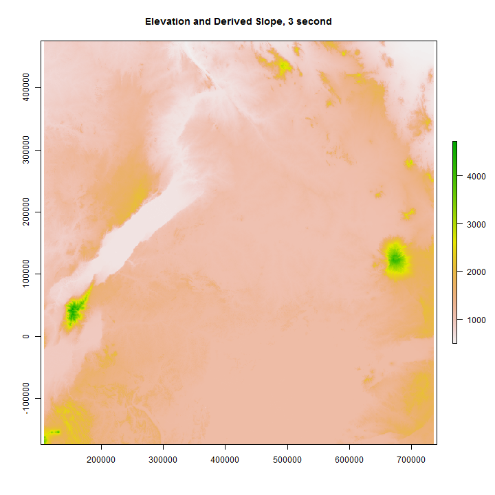

### School locations

**Folder:** Schools  
**File Name:** Uganda_schools.shp  
**Source:** Unknown  
**Description:** These data were sent by R.W. Snow in 2010  
**Class:** point  
**Derived Covariates:**  
prp, cls, dst,

```
class       : SpatialPointsDataFrame
nfeatures   : 10822
extent      : 120098, 722128, -159709, 420560  (xmin, xmax, ymin, ymax)
coord. ref. : NA
nvariables  : 12
```

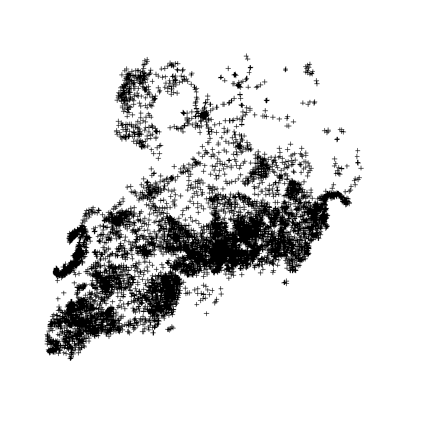

### Digitized Building Locations (OSM), 2013

**Folder:** Buildings  
**File Name:** buildings.shp  
**Source:** Open Street Map, Downloaded 2013-08-08, http://extract.bbbike.org/  
**Description:** These data were downloaded as part of a per-country package of data layers made availalble as shapefiles through the http://extract.bbbike.org website, extracted from the Open Street Map (OSM) database.  
**Class:** polygon  
**Derived Covariates:**  
prp, cls, dst,

```
class       : SpatialPolygonsDataFrame
nfeatures   : 152029
extent      : 150125, 707019, -146470, 470237  (xmin, xmax, ymin, ymax)
coord. ref. : NA
nvariables  : 3
```

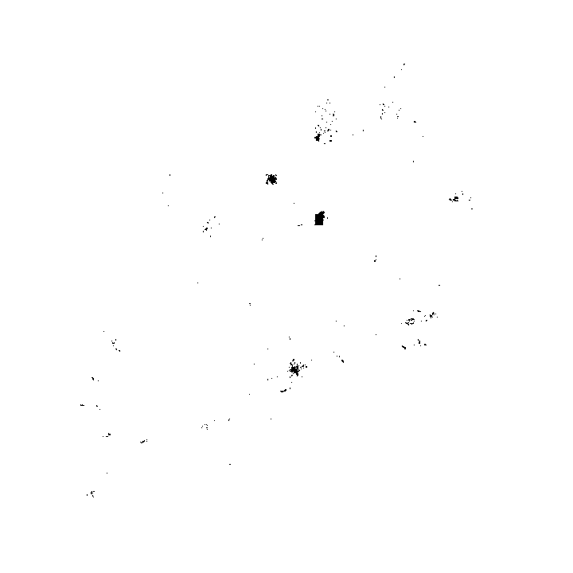

### Natural Feature Polygons (OSM), 2013

**Folder:** Natural  
**File Name:** natural.shp  
**Source:** Open Street Map, Downloaded 2013-08-08, http://extract.bbbike.org/  
**Description:** These data were downloaded as part of a per-country package of data layers made availalble as shapefiles through the http://extract.bbbike.org website, extracted from the Open Street Map (OSM) database.  
**Class:** polygon  
**Derived Covariates:**  
prp, cls, dst,

```
class       : SpatialPolygonsDataFrame
nfeatures   : 1150
extent      : 110937, 701213, -155079, 461544  (xmin, xmax, ymin, ymax)
coord. ref. : NA
nvariables  : 3
```

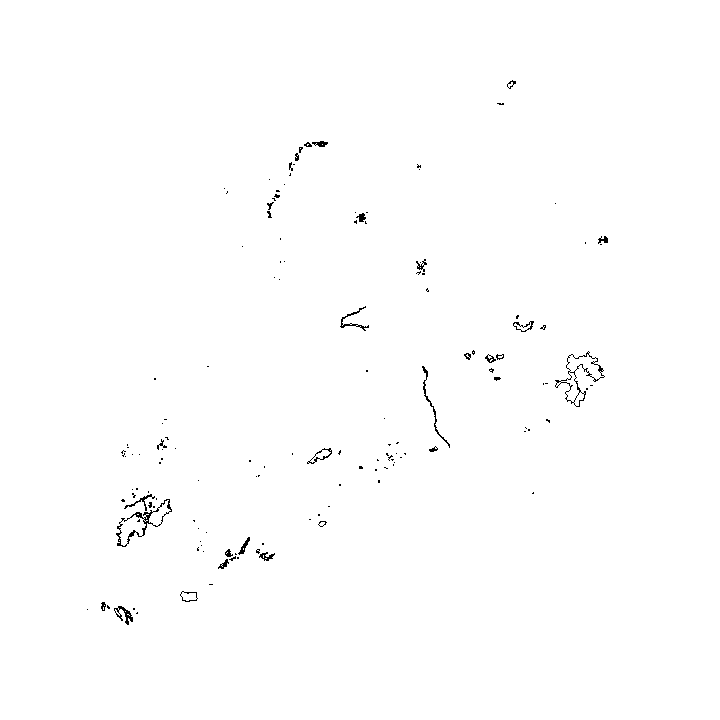

### Place points (OSM), 2013

**Folder:** Places  
**File Name:** places.shp  
**Source:** Open Street Map, Downloaded 2013-08-08, http://extract.bbbike.org/  
**Description:** These data were downloaded as part of a per-country package of data layers made availalble as shapefiles through the http://extract.bbbike.org website, extracted from the Open Street Map (OSM) database.  
**Class:** point  
**Derived Covariates:**  
prp, cls, dst,

```
class       : SpatialPointsDataFrame
nfeatures   : 6744
extent      : 110416, 731735, -160439, 470172  (xmin, xmax, ymin, ymax)
coord. ref. : NA
nvariables  : 6
```

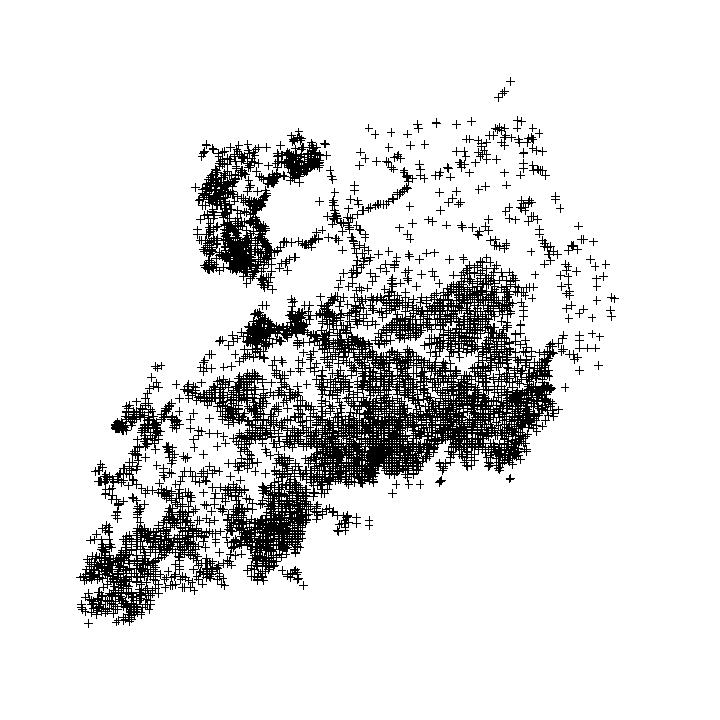

### Points of Interest Locations (OSM), 2013

**Folder:** Points  
**File Name:** points.shp  
**Source:** Open Street Map, Downloaded 2013-08-08, http://extract.bbbike.org/  
**Description:** These data were downloaded as part of a per-country package of data layers made availalble as shapefiles through the http://extract.bbbike.org website, extracted from the Open Street Map (OSM) database.  
**Class:** point  
**Derived Covariates:**  
prp, cls, dst,

```
class       : SpatialPointsDataFrame
nfeatures   : 3173
extent      : 114810, 682927, -165948, 437429  (xmin, xmax, ymin, ymax)
coord. ref. : NA
nvariables  : 4
```

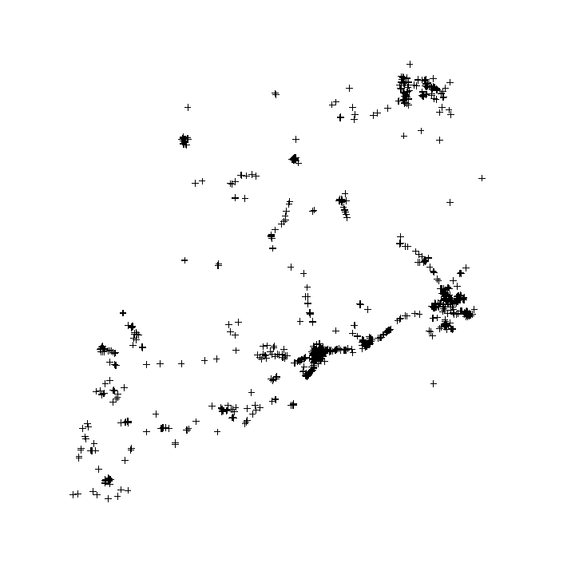

### Railways (OSM), 2013

**Folder:** Railways  
**File Name:** railways.shp  
**Source:** Open Street Map, Downloaded 2013-08-08, http://extract.bbbike.org/  
**Description:** These data were downloaded as part of a per-country package of data layers made availalble as shapefiles through the http://extract.bbbike.org website, extracted from the Open Street Map (OSM) database.  
**Class:** linear  
**Derived Covariates:**  
prp, cls, dst,

```
class       : SpatialLinesDataFrame
nfeatures   : 158
extent      : 173377, 650493, 17593, 333029  (xmin, xmax, ymin, ymax)
coord. ref. : NA
nvariables  : 3
```

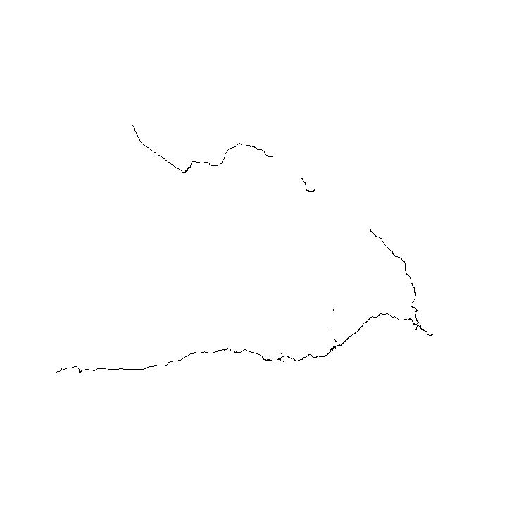

### Waterways (OSM), 2013

**Folder:** Wtrways  
**File Name:** waterways.shp  
**Source:** Open Street Map, Downloaded 2013-08-08, http://extract.bbbike.org/  
**Description:** These data were downloaded as part of a per-country package of data layers made availalble as shapefiles through the http://extract.bbbike.org website, extracted from the Open Street Map (OSM) database.  
**Class:** linear  
**Derived Covariates:**  
prp, cls, dst,

```
class       : SpatialLinesDataFrame
nfeatures   : 1610
extent      : 110451, 732115, -174203, 473670  (xmin, xmax, ymin, ymax)
coord. ref. : NA
nvariables  : 4
```

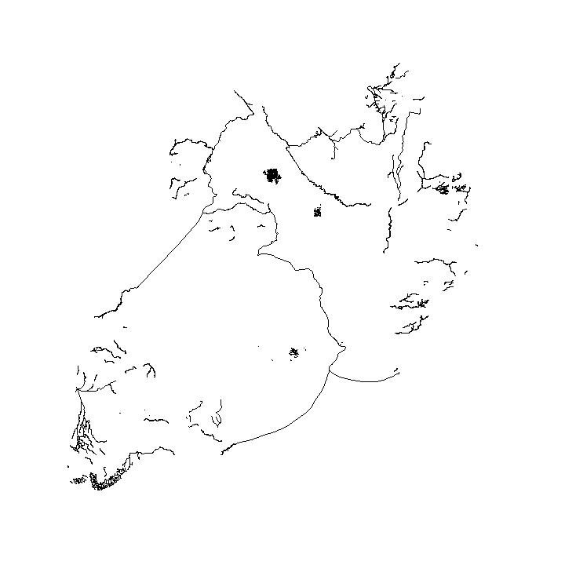

### Delineated Land Uses (OSM), 2013

**Folder:** Uses  
**File Name:** landuse.shp  
**Source:** Open Street Map, Downloaded 2013-08-08, http://extract.bbbike.org/  
**Description:** These data were downloaded as part of a per-country package of data layers made availalble as shapefiles through the http://extract.bbbike.org website, extracted from the Open Street Map (OSM) database.  
**Class:** polygon  
**Derived Covariates:**  
prp, cls, dst,

```
class       : SpatialPolygonsDataFrame
nfeatures   : 1926
extent      : 108789, 721739, -146393, 469583  (xmin, xmax, ymin, ymax)
coord. ref. : NA
nvariables  : 3
```